# exploratoryAnalysis

```python
import pandas as pd
import numpy as np
import matplotlib.pyplot as plt
import seaborn as sns

plt.style.use('tableau-colorblind10')

%matplotlib inline
```

```python
pd.set_option('max_columns', 77)
```

```python
data = pd.read_csv('FullBettingDF.csv', index_col=0)
data
```

|  | Div | Date | HomeTeam | AwayTeam | FTHG | FTAG | FTR | HTHG | HTAG | HTR | Referee | HS | AS | HST | AST | HF | AF | HC | AC | HY | AY | HR | AR | B365H | B365D | B365A | BWH | BWD | BWA | … |
| --- | --- | --- | --- | --- | --- | --- | --- | --- | --- | --- | --- | --- | --- | --- | --- | --- | --- | --- | --- | --- | --- | --- | --- | --- | --- | --- | --- | --- | --- | --- |
| 0 | E0 | 14/08/10 | Aston Villa | West Ham | 3.0 | 0.0 | H | 2.0 | 0.0 | H | M Dean | 23.0 | 12.0 | 11.0 | 2.0 | 15.0 | 15.0 | 16.0 | 7.0 | 1.0 | 2.0 | 0.0 | 0.0 | 2.00 | 3.30 | 4.0 | 1.85 | 3.40 | 4.10 | … |
| 1 | E0 | 14/08/10 | Blackburn | Everton | 1.0 | 0.0 | H | 1.0 | 0.0 | H | P Dowd | 7.0 | 17.0 | 2.0 | 12.0 | 19.0 | 14.0 | 1.0 | 3.0 | 2.0 | 1.0 | 0.0 | 0.0 | 2.88 | 3.25 | 2.5 | 2.75 | 3.25 | 2.45 | … |
| 2 | E0 | 14/08/10 | Bolton | Fulham | 0.0 | 0.0 | D | 0.0 | 0.0 | D | S Attwell | 13.0 | 12.0 | 9.0 | 7.0 | 12.0 | 13.0 | 4.0 | 8.0 | 1.0 | 3.0 | 0.0 | 0.0 | 2.20 | 3.30 | 3.4 | 2.15 | 3.25 | 3.25 | … |
| 3 | E0 | 14/08/10 | Chelsea | West Brom | 6.0 | 0.0 | H | 2.0 | 0.0 | H | M Clattenburg | 18.0 | 10.0 | 13.0 | 4.0 | 10.0 | 10.0 | 3.0 | 1.0 | 1.0 | 0.0 | 0.0 | 0.0 | 1.17 | 7.00 | 17.0 | 1.15 | 6.75 | 16.00 | … |
| 4 | E0 | 14/08/10 | Sunderland | Birmingham | 2.0 | 2.0 | D | 1.0 | 0.0 | H | A Taylor | 6.0 | 13.0 | 2.0 | 7.0 | 13.0 | 10.0 | 3.0 | 6.0 | 3.0 | 3.0 | 1.0 | 0.0 | 2.10 | 3.30 | 3.6 | 2.15 | 3.20 | 3.30 | … |
| ... | ... | ... | ... | ... | ... | ... | ... | ... | ... | ... | ... | ... | ... | ... | ... | ... | ... | ... | ... | ... | ... | ... | ... | ... | ... | ... | ... | ... | ... | … |
| 3415 | E0 | 12/05/2019 | Liverpool | Wolves | 2.0 | 0.0 | H | 1.0 | 0.0 | H | M Atkinson | 13.0 | 7.0 | 5.0 | 2.0 | 3.0 | 11.0 | 4.0 | 1.0 | 0.0 | 2.0 | 0.0 | 0.0 | 1.30 | 6.00 | 11.0 | 1.30 | 5.75 | 9.50 | … |
| 3416 | E0 | 12/05/2019 | Man United | Cardiff | 0.0 | 2.0 | A | 0.0 | 1.0 | A | J Moss | 26.0 | 13.0 | 10.0 | 4.0 | 9.0 | 6.0 | 11.0 | 2.0 | 3.0 | 3.0 | 0.0 | 0.0 | 1.28 | 6.50 | 11.0 | 1.25 | 6.25 | 11.00 | … |
| 3417 | E0 | 12/05/2019 | Southampton | Huddersfield | 1.0 | 1.0 | D | 1.0 | 0.0 | H | L Probert | 10.0 | 10.0 | 3.0 | 3.0 | 8.0 | 6.0 | 4.0 | 3.0 | 0.0 | 1.0 | 0.0 | 0.0 | 1.44 | 4.75 | 8.5 | 1.42 | 4.75 | 7.25 | … |
| 3418 | E0 | 12/05/2019 | Tottenham | Everton | 2.0 | 2.0 | D | 1.0 | 0.0 | H | A Marriner | 11.0 | 17.0 | 3.0 | 9.0 | 10.0 | 13.0 | 7.0 | 4.0 | 0.0 | 2.0 | 0.0 | 0.0 | 2.20 | 3.50 | 3.5 | 2.10 | 3.50 | 3.50 | … |
| 3419 | E0 | 12/05/2019 | Watford | West Ham | 1.0 | 4.0 | A | 0.0 | 2.0 | A | C Kavanagh | 17.0 | 16.0 | 8.0 | 9.0 | 10.0 | 10.0 | 7.0 | 2.0 | 1.0 | 0.0 | 1.0 | 0.0 | 2.25 | 3.75 | 3.2 | 2.20 | 3.70 | 3.10 | … |

3420 rows × 77 columns

```python
data.head(1)
```

|  | Div | Date | HomeTeam | AwayTeam | FTHG | FTAG | FTR | HTHG | HTAG | HTR | Referee | HS | AS | HST | AST | HF | AF | HC | AC | HY | AY | HR | AR | B365H | B365D | B365A | BWH | BWD | BWA | … |
| --- | --- | --- | --- | --- | --- | --- | --- | --- | --- | --- | --- | --- | --- | --- | --- | --- | --- | --- | --- | --- | --- | --- | --- | --- | --- | --- | --- | --- | --- | --- |
| 0 | E0 | 14/08/10 | Aston Villa | West Ham | 3.0 | 0.0 | H | 2.0 | 0.0 | H | M Dean | 23.0 | 12.0 | 11.0 | 2.0 | 15.0 | 15.0 | 16.0 | 7.0 | 1.0 | 2.0 | 0.0 | 0.0 | 2.0 | 3.3 | 4.0 | 1.85 | 3.4 | 4.1 | … |

# Explanation of my dataset and proof that it is viable

- **HomeTeam**: Team playing at their home ground. They face the team playing away.
- **AwayTeam**: Team playing away from their home ground. They face the team playing at home.
- **FTHG**: Full Time Home Goals. Number of goals home team scored at the end of the match.
- **FTAG**: Full Time Away Goals. Number of goals away team scored at the end of the match.
- **FTR**: Full Time Result. H: Home team won, D: Draw, A: Away team won
- **HTHG**: Half Time Home Goals. Number of goals home team scored until half time.
- **HTAG**: Half Time Away Goals. Number of goals away team scored until half time.
- **HS**: Home Shots. Number of shots home team had in the whole match.
- **AS**: Away Shots. Number of shots away team had in the whole match.
- **HST**: Home Shots on Target. Number of shots home team had on target (at the away teams goal) in the whole match.
- **AST**: Away Shots on Target. Number of shots away team had on target (at the home teams goal) in the whole match.
- **HF**: Home Fouls. Number of fouls home team committed in the whole match.
- **AF**: Away Fouls. Number of fouls away team committed in the whole match.
- **HC**: Home Corners. Number of corners home team had in the whole match.
- **AC**: Away Corners. Number of corners away team had in the whole match.
- **HY**: Home Yellow. Number of yellow cards home team received in the whole match.
- **AY**: Away Yellow. Number of yellow cards away team received in the whole match.
- **HR**: Home Red. Number of red cards home team received in the whole match.
- **AR**: Away Red. Number of red cards away team received in the whole match.
- **B365H**: Bet365Home. Odds of home team winning as per the betting company Bet365.
- **B365D**: Bet365Draw. Odds of a draw as per the betting company Bet365.
- **B365A**: Bet365Away. Odds of away team winning as per the betting company Bet365.

```python
# Drop unnecessary columns
data.drop(data.loc[:, 'BWH':].columns, axis=1, inplace=True)
data.drop(['Div', 'Date', 'Referee', 'HTR'], axis=1, inplace=True)
```

```python
data['FTR'] = data['FTR'].astype('category')
```

Your dataset should:

- include at least 600 observations. (This is the number of rows after tidying your data - see the bullet point below about tidy data.)
- include at least eight variables.
- include at least one qualitative / categorical variable. (This can also be engineered / created.)
- include at least one numeric variable.
- be in a tidy format. In a nutshell, tidy data has each row as a single observation and each column reporting a single variable. You can read more about tidy data in Hadley Wickham’s paper [here]. You may need to do some cleaning and reshaping to tidy your dataset, before you actually get started with your exploration.
- be in a common data format. This includes .csv, .tsv, .txt, and .xls. Basically, there should be a reasonable pandas.read_*() function to open up your data in a tidy format as a pandas DataFrame.

```python
# Include at least 600 observations. (This is the number of rows after tidying your data -
# see the bullet point below about tidy data.)
data.shape[0]

# 3420 observations/rows. Greater than 600, passes first check
```

```
3420
```

```python
# Include at least eight variables.
data.columns.shape[0]

# 22 columns/variables. Greater than 8, passes second check
```

```
22
```

```python
# Include at least one qualitative / categorical variable. (This can also be engineered / created.)
data['FTR'].dtype

# Data type of FTR is categorical, passes third test
```

```
CategoricalDtype(categories=['A', 'D', 'H'], ordered=False)
```

```python
# Include at least one numeric variable.
print('FTHG TYPE: {}\n'.format(data['FTHG'].dtype))
print('DATA TYPES OF WHOLE DATASET: \n{}'.format(data.dtypes))


# Date type of FTHG is float, passes fourth test
# Almost every other variable in this dataset is also numeric
```

```
FTHG TYPE: float64

DATA TYPES OF WHOLE DATASET:
HomeTeam      object
AwayTeam      object
FTHG         float64
FTAG         float64
FTR         category
HTHG         float64
HTAG         float64
HS           float64
AS           float64
HST          float64
AST          float64
HF           float64
AF           float64
HC           float64
AC           float64
HY           float64
AY           float64
HR           float64
AR           float64
B365H        float64
B365D        float64
B365A        float64
dtype: object
```

```python
# Be in a tidy format. In a nutshell, tidy data has each row as a single observation
# and each column reporting a single variable. You can read more about tidy data in Hadley Wickham’s paper [here].
# You may need to do some cleaning and reshaping to tidy your dataset,
# before you actually get started with your exploration.

data.head()

# No missing data. Each row is one instance/observation of a football (soccer) game.
# Each column reports a single variable. Explanation of acronyms can be found at the top of this page.
```

|  | HomeTeam | AwayTeam | FTHG | FTAG | FTR | HTHG | HTAG | HS | AS | HST | AST | HF | AF | HC | AC | HY | AY | HR | AR | B365H | B365D | B365A |
| --- | --- | --- | --- | --- | --- | --- | --- | --- | --- | --- | --- | --- | --- | --- | --- | --- | --- | --- | --- | --- | --- | --- |
| 0 | Aston Villa | West Ham | 3.0 | 0.0 | H | 2.0 | 0.0 | 23.0 | 12.0 | 11.0 | 2.0 | 15.0 | 15.0 | 16.0 | 7.0 | 1.0 | 2.0 | 0.0 | 0.0 | 2.00 | 3.30 | 4.0 |
| 1 | Blackburn | Everton | 1.0 | 0.0 | H | 1.0 | 0.0 | 7.0 | 17.0 | 2.0 | 12.0 | 19.0 | 14.0 | 1.0 | 3.0 | 2.0 | 1.0 | 0.0 | 0.0 | 2.88 | 3.25 | 2.5 |
| 2 | Bolton | Fulham | 0.0 | 0.0 | D | 0.0 | 0.0 | 13.0 | 12.0 | 9.0 | 7.0 | 12.0 | 13.0 | 4.0 | 8.0 | 1.0 | 3.0 | 0.0 | 0.0 | 2.20 | 3.30 | 3.4 |
| 3 | Chelsea | West Brom | 6.0 | 0.0 | H | 2.0 | 0.0 | 18.0 | 10.0 | 13.0 | 4.0 | 10.0 | 10.0 | 3.0 | 1.0 | 1.0 | 0.0 | 0.0 | 0.0 | 1.17 | 7.00 | 17.0 |
| 4 | Sunderland | Birmingham | 2.0 | 2.0 | D | 1.0 | 0.0 | 6.0 | 13.0 | 2.0 | 7.0 | 13.0 | 10.0 | 3.0 | 6.0 | 3.0 | 3.0 | 1.0 | 0.0 | 2.10 | 3.30 | 3.6 |

```python
# Be in a common data format. This includes .csv, .tsv, .txt, and .xls.
# Basically, there should be a reasonable pandas.read_*() function to open up your data in a tidy format
# as a pandas DataFrame.

# data = pd.read_csv('Data/FullBettingDF.csv', index_col=0)

# Data is read in as a .csv file using pd.read_csv()
```

### What is the structure of your dataset?

There are 3420 games in the dataset with 22 features, described above. Most variables are numeric in nature, but the variable FTR is a non-ordinal categorical value. The variables B365H, B365D, and B365A are the betting odds for that particular match given by the betting company Bet365. The variable with the lowest value, is the variable deemed most likely to occur. For example, consider the odds are B365H: 2.00, B365D: 3.30, B365A: 4.0. B365H has the lowest value of 2.00, therefore it is considered the most likely to occur, and Bet365 predicted the home team were most likely to win.

### What is/are the main feature(s) of interest in your dataset?

I'm interested in figuring out what features are best for predicting the FTR (Full Time Result) of a match.

### What features in the dataset do you think will help support your investigation into your feature(s) of interest?

I expect that the number of shots each team has (HS, AS) as well as the number of shots on target each team has (HST, AST) will have a large factor in deciding the FTR. The number of corners may also have an effect in deciding the FTR, but to a smaller degree.

# Exploratory visualizations

## Univariate Exploration

### Home team shots and shots on target

```python
data.head()
```

|  | HomeTeam | AwayTeam | FTHG | FTAG | FTR | HTHG | HTAG | HS | AS | HST | AST | HF | AF | HC | AC | HY | AY | HR | AR | B365H | B365D | B365A |
| --- | --- | --- | --- | --- | --- | --- | --- | --- | --- | --- | --- | --- | --- | --- | --- | --- | --- | --- | --- | --- | --- | --- |
| 0 | Aston Villa | West Ham | 3.0 | 0.0 | H | 2.0 | 0.0 | 23.0 | 12.0 | 11.0 | 2.0 | 15.0 | 15.0 | 16.0 | 7.0 | 1.0 | 2.0 | 0.0 | 0.0 | 2.00 | 3.30 | 4.0 |
| 1 | Blackburn | Everton | 1.0 | 0.0 | H | 1.0 | 0.0 | 7.0 | 17.0 | 2.0 | 12.0 | 19.0 | 14.0 | 1.0 | 3.0 | 2.0 | 1.0 | 0.0 | 0.0 | 2.88 | 3.25 | 2.5 |
| 2 | Bolton | Fulham | 0.0 | 0.0 | D | 0.0 | 0.0 | 13.0 | 12.0 | 9.0 | 7.0 | 12.0 | 13.0 | 4.0 | 8.0 | 1.0 | 3.0 | 0.0 | 0.0 | 2.20 | 3.30 | 3.4 |
| 3 | Chelsea | West Brom | 6.0 | 0.0 | H | 2.0 | 0.0 | 18.0 | 10.0 | 13.0 | 4.0 | 10.0 | 10.0 | 3.0 | 1.0 | 1.0 | 0.0 | 0.0 | 0.0 | 1.17 | 7.00 | 17.0 |
| 4 | Sunderland | Birmingham | 2.0 | 2.0 | D | 1.0 | 0.0 | 6.0 | 13.0 | 2.0 | 7.0 | 13.0 | 10.0 | 3.0 | 6.0 | 3.0 | 3.0 | 1.0 | 0.0 | 2.10 | 3.30 | 3.6 |

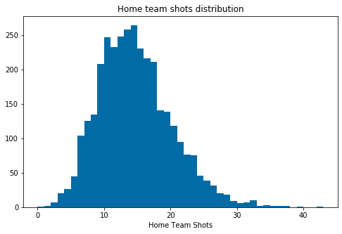

```python
binsize = 1
bins = np.arange(0, data['HS'].max()+binsize, binsize)

plt.figure(figsize=[8, 5])
plt.hist(data = data, x = 'HS', bins = bins)
plt.title('Home team shots distribution')
plt.xlabel('Home Team Shots');
```

Plotting a simple histogram of HS shows us a normal distribution of shots, with a few exceptions where the home team had an abnormally large amount of shots. The peak of the distribution seems to be around 15 shots.

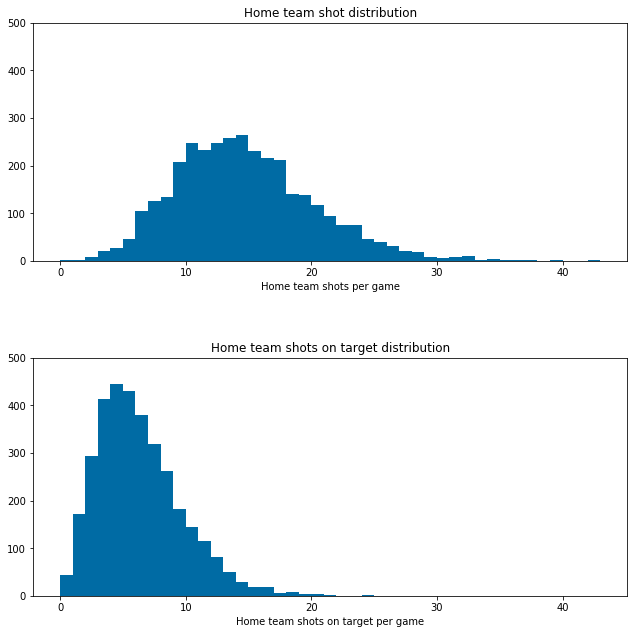

```python
figure, axes = plt.subplots(nrows=2, ncols=1, figsize=(10,10))
binsize = 1
bins = np.arange(0, data['HS'].max()+binsize, binsize)
ticks = [0, 100, 200, 300, 400, 500]

axes[0].hist(data = data, x = 'HS', bins = bins)
axes[0].set_title('Home team shot distribution')
axes[0].set_xlabel('Home team shots per game')
axes[0].set_yticks(ticks)

axes[1].hist(data = data, x = 'HST', bins = bins)
axes[1].set_title('Home team shots on target distribution')
axes[1].set_xlabel('Home team shots on target per game')
axes[1].set_yticks(ticks)

figure.tight_layout(pad=5);
```

Comparing HS and HST shows us that, as expected, the HST distribution shows a largely right skewed distribution as we would expect players to miss some of the shots that they take, some missing a lot more than others.

### Away team shots and shots on target

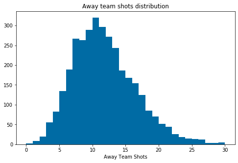

```python
binsize = 1
bins = np.arange(0, data['AS'].max()+binsize, binsize)

plt.figure(figsize=[8, 5])
plt.hist(data = data, x = 'AS', bins = bins)
plt.title('Away team shots distribution')
plt.xlabel('Away Team Shots');
```

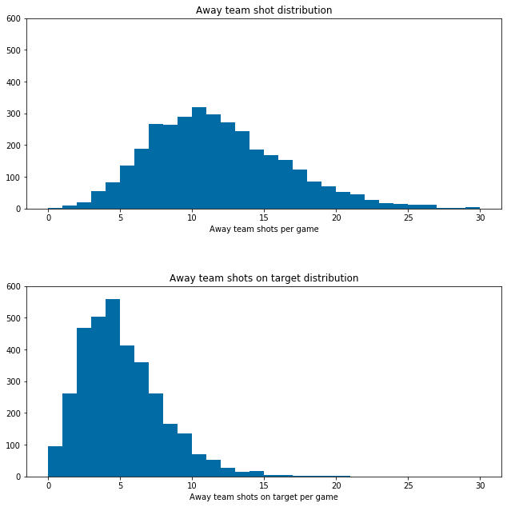

```python
figure, axes = plt.subplots(nrows=2, ncols=1, figsize=(10,10))
binsize = 1
bins = np.arange(0, data['AS'].max()+binsize, binsize)
ticks = [0, 100, 200, 300, 400, 500, 600]

axes[0].hist(data = data, x = 'AS', bins = bins)
axes[0].set_title('Away team shot distribution')
axes[0].set_xlabel('Away team shots per game')
axes[0].set_yticks(ticks)

axes[1].hist(data = data, x = 'AST', bins = bins)
axes[1].set_title('Away team shots on target distribution')
axes[1].set_xlabel('Away team shots on target per game')
axes[1].set_yticks(ticks)

figure.tight_layout(pad=5);
```

When making the same comparison as above but this time with the away team, we see a largely similar distribution, with away team shot distribution being of a fairly normal distribution, whilst away team shots on target being right skewed. However, we really start to see the difference between home team and away team when we compare the two directly together, which we will see below.

### Comparing home team shots to away team shots

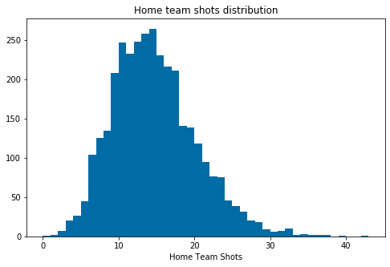

```python
binsize = 1
bins = np.arange(0, data['HS'].max()+binsize, binsize)

plt.figure(figsize=[8, 5])
plt.hist(data = data, x = 'HS', bins = bins)
plt.title('Home team shots distribution')
plt.xlabel('Home Team Shots');
```

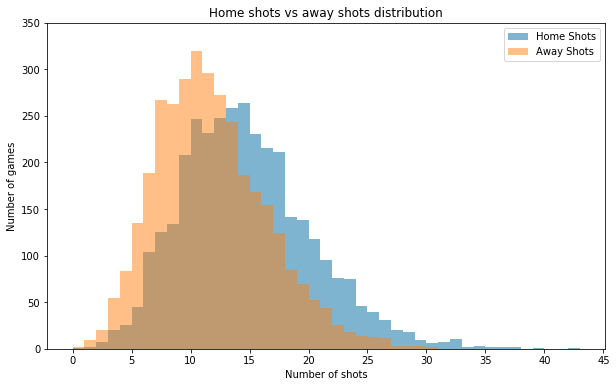

```python
binsize = 1
bins = np.arange(0, data['HS'].max()+binsize, binsize)
yticks = [0, 50, 100, 150, 200, 250, 300, 350]
xticks = [0, 5, 10, 15, 20, 25, 30, 35, 40, 45]
plt.figure(figsize=[10, 6])

plt.hist(data['HS'], bins, alpha=0.5, label='Home Shots')
plt.hist(data['AS'], bins, alpha=0.5, label='Away Shots')
plt.yticks(yticks)
plt.xticks(xticks)
plt.xlabel('Number of shots')
plt.ylabel('Number of games')
plt.title('Home shots vs away shots distribution')
plt.legend(loc='upper right');
```

This graph shows us that the peaks between home team shots and away team shots have a difference of about 5 shots, in favour of the home team. This is to be expected as the home team will have the support of their home fans to push them to win the game, therefore leading to the home team having a greater advantage.

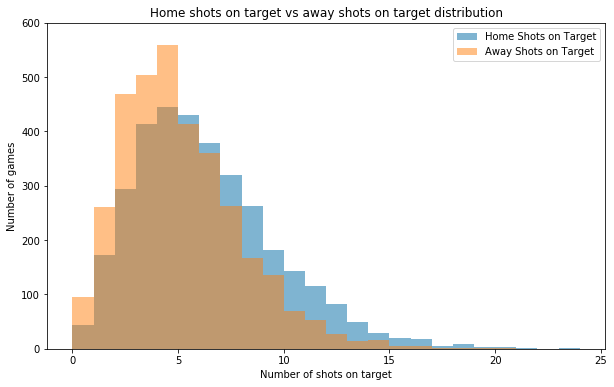

```python
binsize = 1
bins = np.arange(0, data['HST'].max()+binsize, binsize)
yticks = [0, 100, 200, 300, 400, 500, 600]
xticks = [0, 5, 10, 15, 20, 25]
plt.figure(figsize=[10, 6])

plt.hist(data['HST'], bins, alpha=0.5, label='Home Shots on Target')
plt.hist(data['AST'], bins, alpha=0.5, label='Away Shots on Target')
plt.yticks(yticks)
plt.xticks(xticks)
plt.xlabel('Number of shots on target')
plt.ylabel('Number of games')
plt.title('Home shots on target vs away shots on target distribution')
plt.legend(loc='upper right');
```

When comparing the same graph as before but this time with shots on target, we see that the two histograms follow a very similar distribution with a lot of overlap. Both peak at 4 shots on target per game. However, higher than 4 shots on target, and the home team is always greater than the away team, and lower than 4 shots on target, the away team is always greater than the home team, showing once again that there seems to be a positive effect on the home team in terms of shots on target.

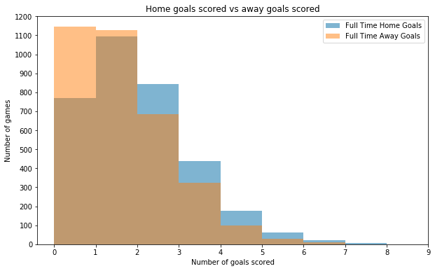

```python
binsize = 1
bins = np.arange(0, data['FTHG'].max()+binsize, binsize)
yticks = [0, 100, 200, 300, 400, 500, 600, 700, 800, 900, 1000, 1100, 1200]
xticks = [0, 1, 2, 3, 4, 5, 6, 7, 8, 9]
plt.figure(figsize=[10, 6])

plt.hist(data['FTHG'], bins, alpha=0.5, label='Full Time Home Goals')
plt.hist(data['FTAG'], bins, alpha=0.5, label='Full Time Away Goals')
plt.yticks(yticks)
plt.xticks(xticks)
plt.xlabel('Number of goals scored')
plt.ylabel('Number of games')
plt.title('Home goals scored vs away goals scored')
plt.legend(loc='upper right');
```

The graph above shows the distribution of goals between the home team and away team. The distribution is strongly right skewed, which is to be expected as each game starts with both teams having scored 0 goals, and it becoming increasingly difficult to score more goals as the game goes on. However, there is a difference, in that the peak for the away team is at 0 goals, and the peak for the home team is at 1 goal. Higher than 1 goal scored, and the home team always has a higher amount that the away team, showing that generally, the home team wins more games than the away team.

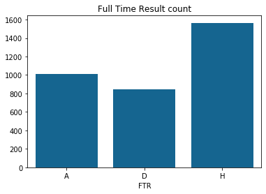

```python
base_color = sns.color_palette()[0]
sns.countplot(data = data, x = 'FTR', color = base_color)
plt.ylabel('')
plt.title('Full Time Result count');
```

Lastly, we can perform a simple countplot to show how often each result occurs, with the home team clearly winning the majority of matches, and a draw being the least likely.

## Bivariate Exploration

```python
numeric_vars = ['FTHG', 'FTAG', 'HTHG', 'HTAG', 'HS', 'AS', 'HST', 'AST', 'HF', 'AF', 'HC', 'AC', 'HY', 'AY', 'HR', 'AR']
categoric_vars = ['FTR']
```

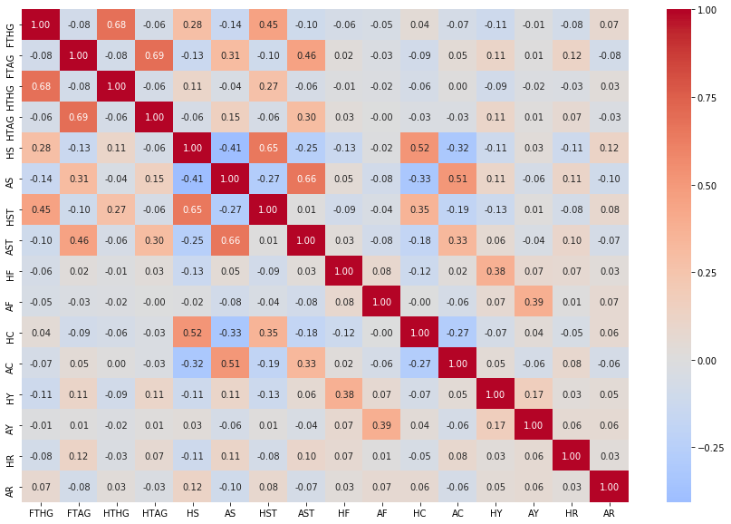

```python
plt.figure(figsize = [15, 10])
sns.heatmap(data[numeric_vars].corr(), annot = True, fmt = '.2f',
           cmap = 'coolwarm', center = 0);
```

We also see that HS and AS have a negative correlation with each other, which is to be expected, as if the home team has more shots, they likely have more possession, making it less likely for the away team to get the ball and then have a shot.

There is also a strong positive correlation between HS with HC, and AS with AC. This is likely due to the fact that a team that has a lot of shots is likely to also have a lot of corners, as those shots end up being deflected behind the goal for a corner.

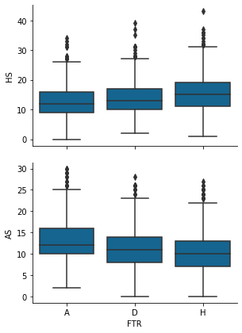

```python
# plot matrix of numeric features against categorical features.
# can use a larger sample since there are fewer plots and they're simpler in nature.

def boxgrid(x, y, **kwargs):
    """ Quick hack for creating box plots with seaborn's PairGrid. """
    base_color = sns.color_palette()[0]
    sns.boxplot(x, y, color = base_color)

plt.figure(figsize = [10, 10])
g = sns.PairGrid(data = data, y_vars = ['HS', 'AS'], x_vars = categoric_vars,
                size = 3, aspect = 1.5)
g.map(boxgrid)
plt.show();
```

The above plot shows us the relationship between HS and AS with FTR taken into account. Unsurprisingly, as HS increases, the likelihood of a home win also increases. Home wins have a median HS of roughly 15, whereas the HS where the away team wins is lower at roughly 12.

The inverse can also be said for AS, as the home team is more likely to win if there are fewer AS.

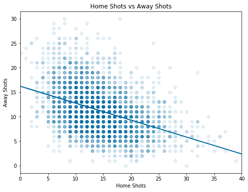

```python
# scatter plot showing home shots vs away shots

plt.figure(figsize = [8, 6])
plt.scatter(data = data, x = 'HS', y = 'AS', alpha = 1/10)
plt.xlim([0, 40])
plt.xlabel('Home Shots')
plt.yticks([0, 5, 10, 15, 20, 25, 30, 35, 40, 45])
plt.ylabel('Away Shots')
plt.title('Home Shots vs Away Shots')
m, b = np.polyfit(data['HS'], data['AS'], 1)
plt.plot(data['HS'], m*data['HS'] + b);
```

Scatter plot of home shots vs away shots, with the addition of a linear regression plot. This shows us the negative correlation between the two variables, with homes shots increasing causing a decrease in away shots.

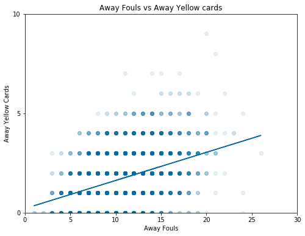

```python
plt.figure(figsize = [8, 6])
plt.scatter(data = data, x = 'AF', y = 'AY', alpha = 1/10)
plt.xlim([0, 30])
plt.ylim([0,10])
plt.xlabel('Away Fouls')
plt.yticks([0, 5, 10])
plt.ylabel('Away Yellow Cards')
plt.title('Away Fouls vs Away Yellow cards')
m, b = np.polyfit(data['AF'], data['AY'], 1)
plt.plot(data['AF'], m*data['AF'] + b);
```

Another scatter plot, this one showing away fouls vs away yellow cards. As we see, there is a positive correlation between the two. It would be interesting the see what effect this had on the FTR, something to check out in the multivariate exploration phase.

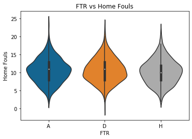

```python
violin_plot = sns.violinplot(x='FTR', y='HF', data=data)
violin_plot.set_title('FTR vs Home Fouls')
violin_plot.set_ylabel('Home Fouls')
violin_plot.set_xlabel('FTR');
```

Above is a violin plot showing FTR vs home fouls. As we can see, there is not that much variation, with a majority number of fouls of roughly 11 being commited per game. What we can see though, is that when the home team wins, the median number of fouls is lower than if the result was a draw or the away team winning.

### Talk about some of the relationships you observed in this part of the investigation. How did the feature(s) of interest vary with other features in the dataset?

FTHG had quite a high correlation with the number of shots taken, which is what we would expect, as the more shtos taken, the more likely one of them is to go in, theoretically. We also saw the negative correlation between HS and AS, which further backs up the point that the more shots that team has, the more likely they are to win, as the other team is unlikely to have as many shots, therefore fewer chances to score.

### Did you observe any interesting relationships between the other features (not the main feature(s) of interest)?

There were some interesting relationships between away yellow cards and away fouls, however it was not unexpected. We would have expected the number of yellow cards to increase for the team with more fouls.

## Multivariate Exploration

```python
# Create a dataframe for one season. Therefore we only have to deal with 20 teams.
dataSeason = data[0:380]
```

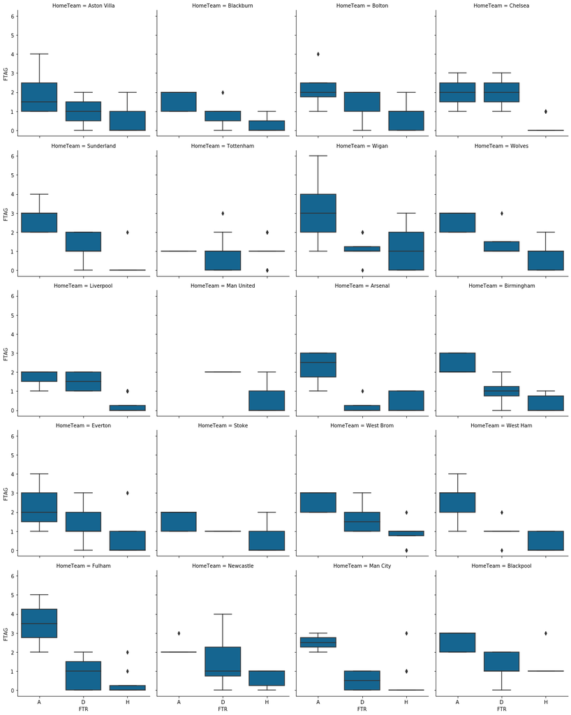

```python
g = sns.FacetGrid(data = dataSeason, col = 'HomeTeam', height = 4, col_wrap=4)
g.map(sns.boxplot, 'FTR', 'FTAG');
```

In this plot, we can compare the number of goals each team conceded when they played at home, and the effect it had on FTR. For example, we see that for Fulham, when they play at home and lose, they concede a median of 3.5 goals, which shows they have a relatively weak defence, especially compared to a team like Chelsea, who concede a median of 2 goals when they lose at home.

Instances where there is no box plot, for example, a FTR of 'A' when the home team is 'Man United', is because there was no occurence for that season, so Man United did not lose to the away team when they played at home, during that season.

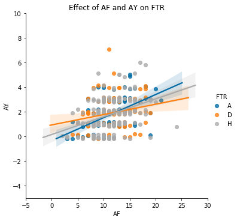

```python
ylimit = [-5, 10]
xlimit = [-5, 30]
sns.lmplot(x='AF', y='AY', hue='FTR',
           data=dataSeason,
           fit_reg=True, y_jitter=0.2)
plt.xlim(xlimit)
plt.ylim(ylimit)
plt.title('Effect of AF and AY on FTR')
```

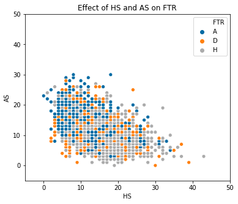

```python
xlimit = [-5, 50]
ylimit = [-5, 50]
plt.figure(figsize=(6,5))
sns.scatterplot(x=data['HS'],
                y=data['AS'],
                hue=data['FTR'])
plt.title('Effect of HS and AS on FTR')
plt.xlim(xlimit)
plt.ylim(ylimit);
```

Above we see a very simple graph showing the the effect that HS and AS had on the FTR. We can clearly see that points towards the lower right are more grey, indicating a FTR of H, and points to the upper left are more blue, indicating a FTR of A. This shows us that when the hometeam has more shots than the away team, they usually tend to win, and the same is true vice versa. Notice however, that whilst there are very few blue points in the lower right, there are a few grey points in the top left, which shows that even in games when the away team has a lot more shots than the home team, the home team still has a chance to win, simply due to the advantage of playing at home.

### Talk about some of the relationships you observed in this part of the investigation. Were there features that strengthened each other in terms of looking at your feature(s) of interest?

I extended my investigation by factoring in more visualizations that looked at the FTR. The facet grid box plot allows us to compare the performance of each team over a whole season, and how many goals they condeded when they either lost, drew, or won. Another interesting plot is the scatter graph showing the distribution of points of HS compared to AS, and the effect on FTR.